# Porównanie wykresów słupkowych i kołowych na przykładzie wizualizacji poparcia kandydatów na prezydentów

Roksana Rogalska

### Dane

Dane przedstawiają poparcie dla kandydatów na prezydentów w wyborach prezydenckich w 2025 roku, zostały pobrane ze strony TVN24.

## Cel eksperymentu

Celem eksperymentu było sprawdzenie, który z przygotowanych wykresów będzie bardziej czytelny i “lepszy” według osób ankietowanych. Chciałam sprawdzić jak odbiorcy postrzegają dane na wykresie słupkowym i kołowym, który z nich będzie bardziej lubiany przez ankietowanych i czy sprawdzi się teza, że to wykresy kołowe gorzej przedstawiają wyniki i są trudniejsze do odczytania.

## Opis eksperymentu

Do przeprowadzenia eksperymentu przygotowłam 2 wykresy przedstawiające te same dane, lecz w inny sposób.

- Wykres słupkowy – uważany za bardziej precyzyjny w odbiorze i umożliwiający łatwiejsze porównanie wartości.
- Wykres kołowy – często uznawany za mniej czytelny ze względu na trudność porównywania kątów.

Po stworzeniu wykresów, przeprowadziłam ankietę, w której zadałam pytanie “Który z prezentowanych wykresów jest lepszy?”.

Oba wykresy przedstawione sa poniżej.

### Wykres 1

Wykres 1 przedstawia poparcie dla kandydatów w postaci słupków.

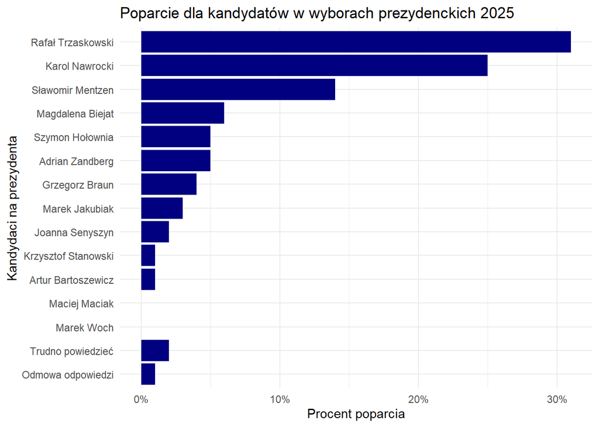

```r
sondaz %>%
  ggplot(aes(y = Kandydat, x = Poparcie_procent)) +
  geom_col(fill="navyblue") + labs(
    title = "Poparcie dla kandydatów w wyborach prezydenckich 2025",
    x = "Procent poparcia",
    y = "Kandydaci na prezydenta") +
  scale_x_continuous(labels = scales::percent_format(scale = 1)) +
  theme_minimal()
```

### Wykres 2

Wykres 2 przedstawia poparcie dla kandydatów na wykresie kołowym.

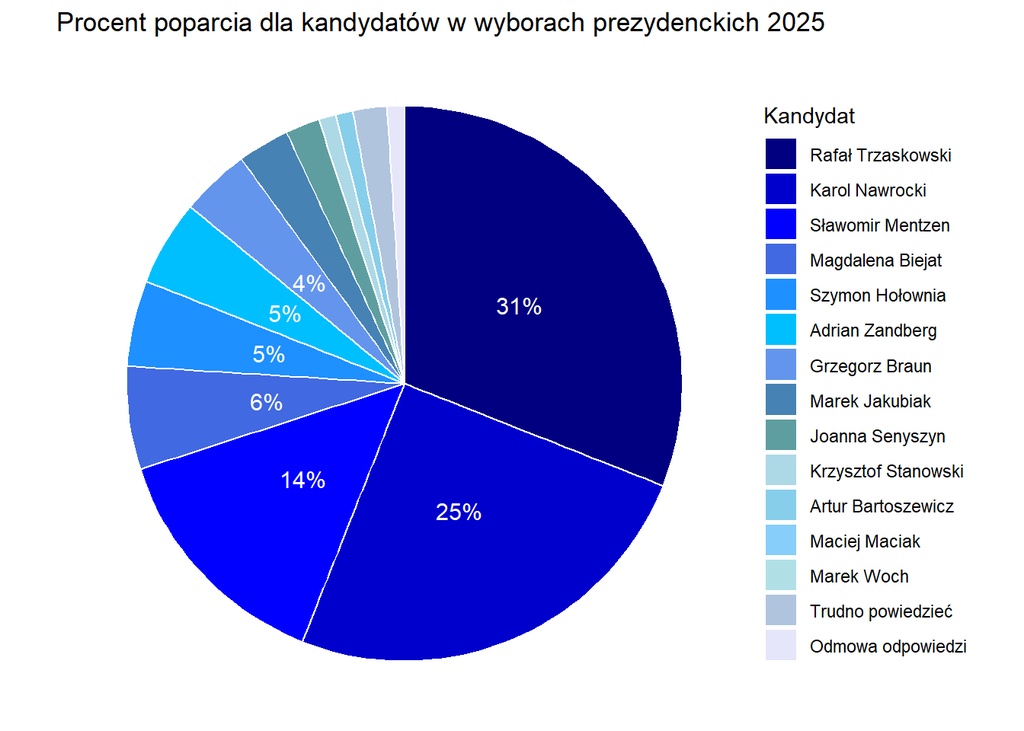

```r
sondaz %>%
  mutate(procent_label = ifelse(Poparcie_procent > 3,
                                paste0(Poparcie_procent, "%"),
                                "")) %>%
  ggplot(aes(x = "", y = Poparcie_procent, fill = Kandydat)) +
  geom_bar(width = 1, stat = "identity", color = "white") +
  coord_polar(theta = "y") +
  geom_text(aes(label = procent_label),
            position = position_stack(vjust = 0.5),
            color = "white",
            size = 4) +
  scale_fill_manual(values = kolory) +
  labs(title = "Procent poparcia dla kandydatów w wyborach prezydenckich 2025") +
  theme_void() +
  theme(legend.position = "right") + guides(fill = guide_legend(reverse = TRUE))
```

## Wyniki badania

W moim badaniu wzięło udział 46 osób, w poniższej tabeli przedstawione są wyniki.

Preferencje wykresów

| Wykres | Liczba | Procent |
| --- | --- | --- |
| Słupkowy | 35 | 76.1 |
| Kołowy | 11 | 23.9 |

## Wnioski i podsumowanie

Zdecydowana większość badanych (ponad 76%) wskazała wykres słupkowy jako bardziej czytelny i preferowany sposób prezentowania danych. Zatem teza opracowana lata temu się sprawdziła, a ankietowani uznali wykres słupkowy za lepszy od kołowego, główne powody to:

- Porównywanie długości słupków jest łatwiejsze niż porównywanie kątów, w szczególności łatiwej odczytać jakie wyniki osiągnęli kandydaci z najniższymi wynikami.
- Wykres słupkowy lepiej prezentuje różnice między kandydatami, szczególnie w środku stawki.
- Wykres kołowy może być atrakcyjny wizualnie, ale mniej praktyczny poznawczo.
- Na wykresie słupkowym w łatwy sposób można od razu zauważyć, który z kandydatów otrzymał 0% poparcia.